##### January 2018

##### Titanic: Machine Learning from Disaster Competition (via Kaggle)

### **Analysis Between One’s Survival Status and Gender**

```r
# loading the dataset in the workspace
# dataset is named "train"
train <- read.csv("train.csv",stringsAsFactors = FALSE)
head(train)
```

```
##   PassengerId Survived Pclass
## 1           1        0      3
## 2           2        1      1
## 3           3        1      3
## 4           4        1      1
## 5           5        0      3
## 6           6        0      3
##                                                  Name    Sex Age SibSp
## 1                             Braund, Mr. Owen Harris   male  22     1
## 2 Cumings, Mrs. John Bradley (Florence Briggs Thayer) female  38     1
## 3                              Heikkinen, Miss. Laina female  26     0
## 4        Futrelle, Mrs. Jacques Heath (Lily May Peel) female  35     1
## 5                            Allen, Mr. William Henry   male  35     0
## 6                                    Moran, Mr. James   male  NA     0
##   Parch           Ticket    Fare Cabin Embarked
## 1     0        A/5 21171  7.2500              S
## 2     0         PC 17599 71.2833   C85        C
## 3     0 STON/O2. 3101282  7.9250              S
## 4     0           113803 53.1000  C123        S
## 5     0           373450  8.0500              S
## 6     0           330877  8.4583              Q
```

```r
# creating a table to display the survival stats
survive<-table(train$Survived)
survive
```

```
##
##   0   1
## 549 342
```

```r
# survival stats organized by gender
survive.sex <- table(train$Sex,train$Survived)
colnames(survive.sex) <- c("No", "Yes")
survive.sex
```

```
##
##           No Yes
##   female  81 233
##   male   468 109
```

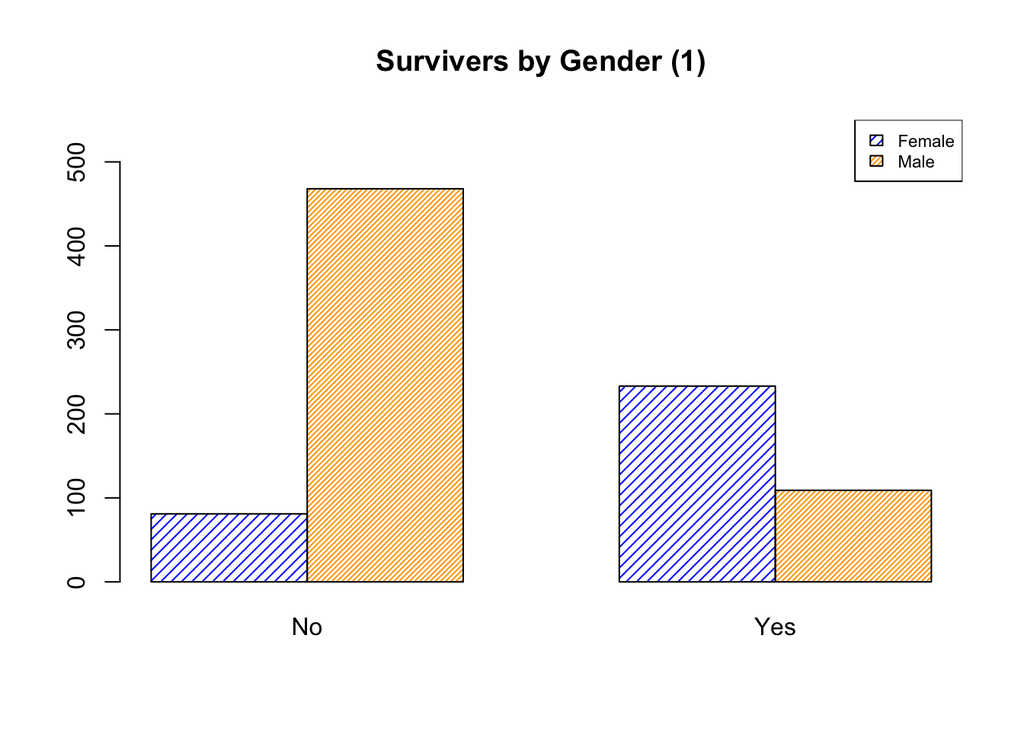

```r
# constructing a barplot to visualize the amount of survivers and nonsurvivers categorized by gender
barplot(survive.sex,beside=TRUE,ylim=c(0,550),col=c("blue","orange"),density=c(20,40,20,40),main="Survivers by Gender (1)")
legend("topright",c("Female", "Male"),density=c(20,40),fill=c("blue","orange"),cex=0.7)
```

### Analysis

This barplot provides a visual comparison between the amount of people for each gender of the same survival status. We see that there are a sigfinicant amount of men who have died compared to women, and a greater amount of women who have survived, despite there being more men on board. The proportion between the amount of people for each survival status is different; there is a greater men to women ratio for those who’ve died than those who have survived. This leads to the second part of my analysis, where I will compute the ratio for men to women and compare the survival stats within each gender.

### Barplot (2) and (3)

```r
# constructing a barplot to visualize the stats above by PROPORTION
sex <- table(train$Sex)
sex
```

```
##
## female   male
##    314    577
```

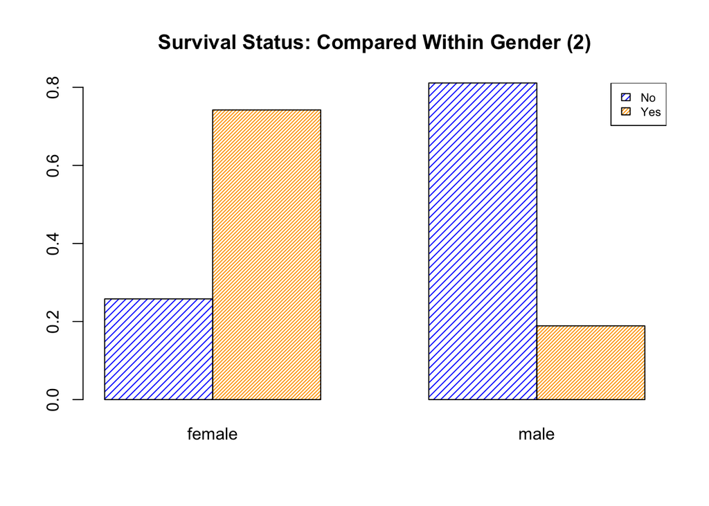

```r
prob.bysurvive.sex <- cbind(survive.sex[1,]/sex[1],survive.sex[2,]/sex[2])
rownames(prob.bysurvive.sex) <- c("No","Yes")
colnames(prob.bysurvive.sex) <- c("female","male")
barplot(prob.bysurvive.sex,beside=TRUE,col=c("blue","orange"),density=c(20,40,20,40),main="Survival Status: Compared Within Gender (2)")
legend("topright",c("No", "Yes"),density=c(20,40),fill=c("blue","orange"),cex=0.7)
```

```r
prob.bysurvive.sex
```

```
##        female      male
## No  0.2579618 0.8110919
## Yes 0.7420382 0.1889081
```

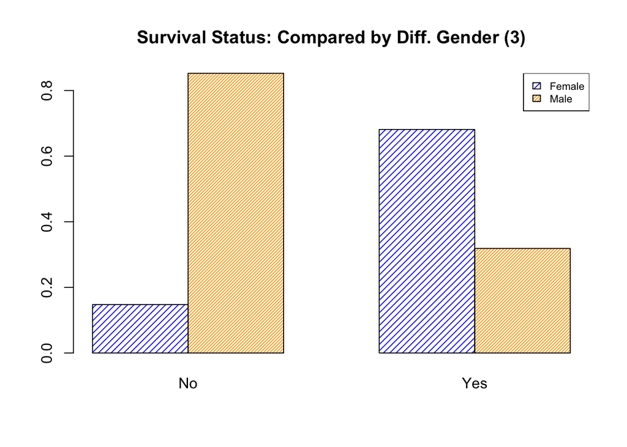

```r
# constructing a barplot to visualize the stats from part 1 organized by the survival status vs gender (AS PROPORTIONS)
prob.bysex.survive <- cbind(survive.sex[,1]/survive[1],survive.sex[,2]/survive[2])
colnames(prob.bysex.survive) <- c("No","Yes")
rownames(prob.bysex.survive) <- c("female","male")
barplot(prob.bysex.survive,beside=TRUE,col=c("blue","orange"),density=c(20,40,20,40),main="Survival Status: Compared by Diff. Gender (3)")
legend("topright",c("Female", "Male"),density=c(20,40),fill=c("blue","orange"),cex=0.7)
```

```r
prob.bysex.survive
```

```
##              No       Yes
## female 0.147541 0.6812865
## male   0.852459 0.3187135
```

### Analysis:

As shown in the barplots above, we see that

- For females, more women survived; for males, more men did not survive. There is also a wider difference between the survival rates in each gender, where ~81.1% men died and only ~25.8% women died.
- Among those who have died, 85.2% are male and 14.8% are female. Among those who survived, 68.1% are female and 31.9% are male. There is a large disparity between the amount of men and women who’ve died, which could be attributed to a greater amount of male passengers from the beginning. This also could serve as one explanation for a smaller female to male ratio for those who’ve survived.
- Nevertheless, all three barplots demonstrate that women had a higher survival rate. While there are implied reasons for this outcome, it raises certain questions like
  - What kind of men survived? Can it be explained by age, fare, class, or amount of family members on board?
  - What kind of women died? Was it just by chance that they did, or were age/fare/class etc factors?
  - *Why did women survive?* Could the amount of family members been a reason too?